# Collinearity, Tests of Nested Models, Categorical Explanatory Variables

SDS 291

November 5, 2019

# Annoucements

- HW 6 assigned: 3.32, 3.44, 3.45 (c only), 3.47, 3.48 (e only), 3.56
- Office hours 1:30 - 3:00pm today
- I’m out of town tonight-Saturday
  - Office hours cancelled on Wed
  - Prof Albert Kim teaching class on Thurs

# Outline for Today

- Interactions
- Multicollinearity
- Thursday with Prof Kim:
  - How to test whether one model is “better” than another?
  - Short lab

# Visualizing Parallel Slopes

```r
NYC <- read.csv("http://bit.ly/nycData")
```

Add `geom_abline()`’s to a `qplot()` visualize your model in the data space. How would we add color to the points to differentiate East from West?

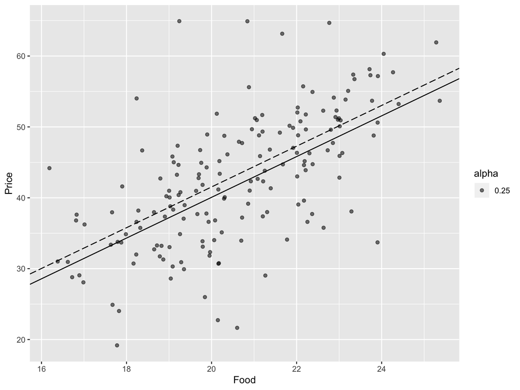

```r
library(ggplot2)

qplot(data = NYC, x = Food, y = Price, geom = "jitter", alpha = 0.25) +
  geom_abline(intercept = -17.430, slope = 2.875) +
  geom_abline(intercept = -17.430 + 1.459, slope = 2.875, linetype = 5)
```

# Interactions - Different Slope Model

Consider the case where $X_1$ is quantitative, but $X_2$ is an variable that can only be 0 or 1 (e.g. $isWoman$). Then,

$$\hat{Y} = \hat{\beta_0} + \hat{\beta_1}X_1 + \hat{\beta_2}X_2 + \hat{\beta_3}X_1X_2$$

So then,  
- For men, $X_2 = 0$ so $\hat{Y} = \hat{\beta_0} + \hat{\beta_1}X_1 + \hat{\beta_2}(0)$ and $\hat{Y} = \hat{\beta_0} + \hat{\beta_1}X_1$ is the fitted regression line for men,  
- For women, $X_2 = 1$ so $\hat{Y} = \hat{\beta_0} + \hat{\beta_1}X_1 + \hat{\beta_2}(1)$ and $\hat{Y} = (\hat{\beta_0} + \hat{\beta_2}) + (\hat{\beta_1}+ \hat{\beta_3})X_1$ is the fitted regression line for women

# RailsTrails Example from homework

```r
library(Stat2Data)
data("RailsTrails")
```

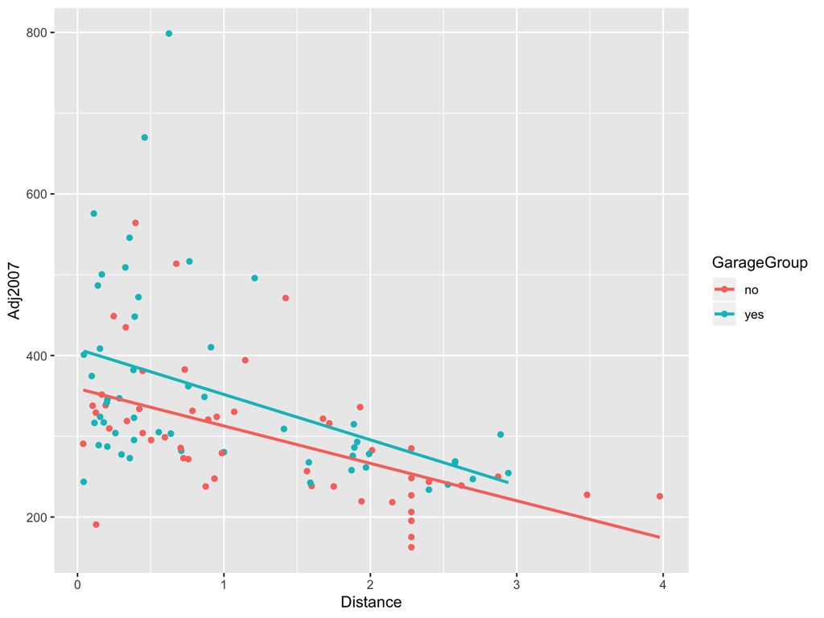

```r
qplot(y = Adj2007, x = Distance, color = GarageGroup, data = RailsTrails) +
  geom_smooth(method = "lm", se = 0)
```

```r
int_mod <- lm(Adj2007 ~ Distance*GarageGroup, data = RailsTrails)
summary(int_mod)
```

```
##
## Call:
## lm(formula = Adj2007 ~ Distance * GarageGroup, data = RailsTrails)
##
## Residuals:
##     Min      1Q  Median      3Q     Max
## -162.46  -51.65  -17.22   30.04  425.76
##
## Coefficients:
##                         Estimate Std. Error t value Pr(>|t|)
## (Intercept)              359.083     21.295  16.862  < 2e-16 ***
## Distance                 -46.302     13.391  -3.458 0.000802 ***
## GarageGroupyes            48.862     28.108   1.738 0.085222 .
## Distance:GarageGroupyes   -9.878     19.366  -0.510 0.611125
## ---
## Signif. codes:  0 '***' 0.001 '**' 0.01 '*' 0.05 '.' 0.1 ' ' 1
##
## Residual standard error: 90.96 on 100 degrees of freedom
## Multiple R-squared:  0.2712, Adjusted R-squared:  0.2494
## F-statistic: 12.41 on 3 and 100 DF,  p-value: 5.785e-07
```

```r
parallel_mod <- lm(Adj2007 ~ Distance + GarageGroup, data = RailsTrails)
summary(parallel_mod)
```

```
##
## Call:
## lm(formula = Adj2007 ~ Distance + GarageGroup, data = RailsTrails)
##
## Residuals:
##     Min      1Q  Median      3Q     Max
## -167.88  -51.55  -21.88   36.79  427.49
##
## Coefficients:
##                Estimate Std. Error t value Pr(>|t|)
## (Intercept)     365.103     17.661  20.673   <2e-16 ***
## Distance        -51.025      9.638  -5.294    7e-07 ***
## GarageGroupyes   37.892     18.032   2.101   0.0381 *
## ---
## Signif. codes:  0 '***' 0.001 '**' 0.01 '*' 0.05 '.' 0.1 ' ' 1
##
## Residual standard error: 90.62 on 101 degrees of freedom
## Multiple R-squared:  0.2693, Adjusted R-squared:  0.2549
## F-statistic: 18.62 on 2 and 101 DF,  p-value: 1.311e-07
```

# Three Category Categorical Variables

### Three parallel slopes model

```r
three_mod <- lm(Adj2007 ~ Distance + BedGroup, data = RailsTrails)
summary(three_mod)
```

```
##
## Call:
## lm(formula = Adj2007 ~ Distance + BedGroup, data = RailsTrails)
##
## Residuals:
##     Min      1Q  Median      3Q     Max
## -130.01  -52.78  -17.42   23.13  407.90
##
## Coefficients:
##                 Estimate Std. Error t value Pr(>|t|)
## (Intercept)      322.786     24.913  12.957  < 2e-16 ***
## Distance         -45.655      9.513  -4.799 5.58e-06 ***
## BedGroup3 beds    44.514     24.873   1.790 0.076540 .
## BedGroup4+ beds   96.447     26.616   3.624 0.000459 ***
## ---
## Signif. codes:  0 '***' 0.001 '**' 0.01 '*' 0.05 '.' 0.1 ' ' 1
##
## Residual standard error: 86.99 on 100 degrees of freedom
## Multiple R-squared:  0.3333, Adjusted R-squared:  0.3133
## F-statistic: 16.67 on 3 and 100 DF,  p-value: 7.417e-09
```

### Three different slopes model

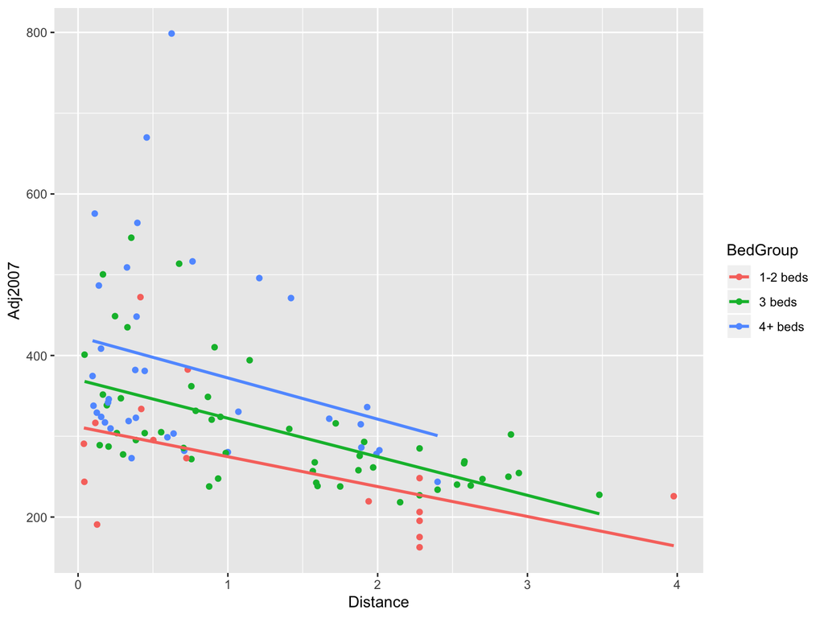

```r
qplot(y = Adj2007, x = Distance, color = BedGroup, data = RailsTrails) +
  geom_smooth(method = "lm", se = 0)
```

```r
three_mod <- lm(Adj2007 ~ Distance*BedGroup, data = RailsTrails)
summary(three_mod)
```

```
##
## Call:
## lm(formula = Adj2007 ~ Distance * BedGroup, data = RailsTrails)
##
## Residuals:
##     Min      1Q  Median      3Q     Max
## -132.12  -54.10  -17.78   24.02  407.23
##
## Coefficients:
##                          Estimate Std. Error t value Pr(>|t|)
## (Intercept)                311.76      32.78   9.510  1.4e-15 ***
## Distance                   -37.02      19.07  -1.941  0.05514 .
## BedGroup3 beds              58.22      38.92   1.496  0.13789
## BedGroup4+ beds            111.50      39.33   2.835  0.00557 **
## Distance:BedGroup3 beds    -10.67      23.07  -0.462  0.64482
## Distance:BedGroup4+ beds   -14.00      28.71  -0.488  0.62683
## ---
## Signif. codes:  0 '***' 0.001 '**' 0.01 '*' 0.05 '.' 0.1 ' ' 1
##
## Residual standard error: 87.75 on 98 degrees of freedom
## Multiple R-squared:  0.3353, Adjusted R-squared:  0.3014
## F-statistic: 9.888 on 5 and 98 DF,  p-value: 1.122e-07
```

# Multicollinearity

**What is it?**

- When one or more of the predictors is strongly correlated with some combination of the other predictors in the set
  - True collinearity is when two factors are associated in an exact, linear combination
  - Near collinearity is when the correlation is high (and thus the $R^2$ is, too)

**Why is it a problem?**

- Individual coefficients and t-tests can be deceptive and unreliable.

# Intuition & and Example

### Intuition: two variables that are highly related to each other

Modeling Weight as a function of Height ($X_1$) and Inseam ($X_2$):
$$weight=\beta_0+\beta_1 Height+ \beta_2 Inseam + \epsilon$$

**Effects of Multicollinearity**

If predictors are highly correlated among themselves:

- The regression coefficients and tests can be extremely variable and difficult to interpret individually.

# Example of Height and Inseam

We want to model Weight as a function of Height, Inseam, and Age

We simulate data, which we call `rdata`, for the purposes of the example with the following correlation matrix

#### Correlation Coefficients

```r
# Correlation Coefficients Matrix
cor(rdata)
```

```
##           weight    height    inseam       age
## weight 1.0000000 0.7885873 0.8073210 0.5002686
## height 0.7885873 1.0000000 0.9559604 0.3773555
## inseam 0.8073210 0.9559604 1.0000000 0.3702648
## age    0.5002686 0.3773555 0.3702648 1.0000000
```

#### Model 1: Height and Age

```r
m1 <- lm(weight ~ height + age, rdata)
summary(m1)
```

```
##
## Call:
## lm(formula = weight ~ height + age, data = rdata)
##
## Residuals:
##      Min       1Q   Median       3Q      Max
## -1.22772 -0.42874 -0.00997  0.32386  1.59323
##
## Coefficients:
##             Estimate Std. Error t value Pr(>|t|)
## (Intercept)  0.06948    0.05993   1.159   0.2491
## height       0.69118    0.06226  11.101   <2e-16 ***
## age          0.23715    0.06322   3.751   0.0003 ***
## ---
## Signif. codes:  0 '***' 0.001 '**' 0.01 '*' 0.05 '.' 0.1 ' ' 1
##
## Residual standard error: 0.5978 on 97 degrees of freedom
## Multiple R-squared:  0.6698, Adjusted R-squared:  0.663
## F-statistic: 98.37 on 2 and 97 DF,  p-value: < 2.2e-16
```

#### Model 2: Inseam and Age

```r
m2 <- lm(weight ~ inseam + age, rdata)
summary(m2)
```

```
##
## Call:
## lm(formula = weight ~ inseam + age, data = rdata)
##
## Residuals:
##      Min       1Q   Median       3Q      Max
## -1.06698 -0.39223 -0.04525  0.37086  1.58523
##
## Coefficients:
##             Estimate Std. Error t value Pr(>|t|)
## (Intercept)  0.08771    0.05733   1.530 0.129282
## inseam       0.71201    0.05925  12.017  < 2e-16 ***
## age          0.23413    0.06020   3.889 0.000184 ***
## ---
## Signif. codes:  0 '***' 0.001 '**' 0.01 '*' 0.05 '.' 0.1 ' ' 1
##
## Residual standard error: 0.571 on 97 degrees of freedom
## Multiple R-squared:  0.6987, Adjusted R-squared:  0.6925
## F-statistic: 112.5 on 2 and 97 DF,  p-value: < 2.2e-16
```

#### Model 3: Height, Inseam and Age

```r
m3 <- lm(weight ~ height+inseam+age, rdata)
summary(m3)
```

```
##
## Call:
## lm(formula = weight ~ height + inseam + age, data = rdata)
##
## Residuals:
##      Min       1Q   Median       3Q      Max
## -1.08853 -0.39992 -0.01961  0.35937  1.58092
##
## Coefficients:
##             Estimate Std. Error t value Pr(>|t|)
## (Intercept)  0.08505    0.05761   1.476 0.143118
## height       0.13131    0.18885   0.695 0.488537
## inseam       0.58788    0.18815   3.125 0.002355 **
## age          0.23052    0.06058   3.805 0.000249 ***
## ---
## Signif. codes:  0 '***' 0.001 '**' 0.01 '*' 0.05 '.' 0.1 ' ' 1
##
## Residual standard error: 0.5725 on 96 degrees of freedom
## Multiple R-squared:  0.7003, Adjusted R-squared:  0.6909
## F-statistic: 74.76 on 3 and 96 DF,  p-value: < 2.2e-16
```

# True collinearity

In most extreme cases - two variables are functions of the other:

- Height ($X_1$)
- Pants inseam ($X_2$)

Let’s assume we’re in a world where everyone’s leg length is the same ratio of their height : inseam = 0.34*height

```
##             weight_true height_true inseam_true
## weight_true   1.0000000   0.9982694   0.9982694
## height_true   0.9982694   1.0000000   1.0000000
## inseam_true   0.9982694   1.0000000   1.0000000
```

```
##
## Call:
## lm(formula = weight_true ~ height_true + inseam_true, data = weightdata)
##
## Residuals:
##     Min      1Q  Median      3Q     Max
## -2.5346 -0.7053  0.1223  0.7281  1.9631
##
## Coefficients: (1 not defined because of singularities)
##             Estimate Std. Error t value Pr(>|t|)
## (Intercept) -0.73503    1.08534  -0.677      0.5
## height_true  3.01134    0.01792 168.050   <2e-16 ***
## inseam_true       NA         NA      NA       NA
## ---
## Signif. codes:  0 '***' 0.001 '**' 0.01 '*' 0.05 '.' 0.1 ' ' 1
##
## Residual standard error: 0.994 on 98 degrees of freedom
## Multiple R-squared:  0.9965, Adjusted R-squared:  0.9965
## F-statistic: 2.824e+04 on 1 and 98 DF,  p-value: < 2.2e-16
```

We constructed that example to be exactly collinear (we’re calling the variables "_true" because they’re perfectly collinear), when it’s unlikely to be the case (two people with the same height might have different length legs).

# How do we detect multicollinearity

- **Warning Signs:** High Correlation Coefficients

Original example (not perfect collinearity): What is the correlation between height and inseam?

```
##   ht_inseam_corr
## 1      0.9559604
```

- **Better Test:** Variance Inflation Factor (VIF)
  - $VIF = \frac{1}{1-{R_i}^2}$ where ${R_i}^2$ is for predicting $X_i$ using the other predictors.
    - VIF > 5 $\sim$ ${R_i}^2$> 80%
    - VIF $\geq$ 5 is questionnable
    - VIF $\geq$ 10 is a problem

# Exploring the VIF - calculating manually

- $VIF = \frac{1}{1-{R_i}^2}$ where ${{R_i}^2}$ is for predicting $X_i$ using the other predictors.
  - The VIF for height used the $R^2$ from the model $Height = \beta_0+ \beta_1 \cdot Inseam + \beta_2 \cdot Age + \epsilon$
  - The VIF for inseam used the $R^2$ from the model $Inseam = \beta_0 + \beta_1 \cdot Height + \beta_2 \cdot Age + \epsilon$
  - **What’s the model for the VIF of Age?**

```r
vif0<-lm(height~inseam+age, data=rdata)
summary(vif0)
```

```
##
## Call:
## lm(formula = height ~ inseam + age, data = rdata)
##
## Residuals:
##      Min       1Q   Median       3Q      Max
## -0.59321 -0.23306 -0.01279  0.18597  0.75928
##
## Coefficients:
##             Estimate Std. Error t value Pr(>|t|)
## (Intercept)  0.02024    0.03090   0.655    0.514
## inseam       0.94533    0.03194  29.595   <2e-16 ***
## age          0.02753    0.03245   0.848    0.398
## ---
## Signif. codes:  0 '***' 0.001 '**' 0.01 '*' 0.05 '.' 0.1 ' ' 1
##
## Residual standard error: 0.3078 on 97 degrees of freedom
## Multiple R-squared:  0.9145, Adjusted R-squared:  0.9127
## F-statistic: 518.7 on 2 and 97 DF,  p-value: < 2.2e-16
```

- Height ($R^2$ = 0.9144948): 1/(1-0.9144948) = 11.6951905

```r
1/(1-summary(vif0)$r.squared)
```

```
## [1] 11.69519
```

```r
vif1<-lm(inseam~height+age, data=rdata)
summary(vif1)
```

```
##
## Call:
## lm(formula = inseam ~ height + age, data = rdata)
##
## Residuals:
##      Min       1Q   Median       3Q      Max
## -0.81922 -0.16569  0.01617  0.19982  0.55612
##
## Coefficients:
##             Estimate Std. Error t value Pr(>|t|)
## (Intercept) -0.02648    0.03097  -0.855    0.395
## height       0.95236    0.03218  29.595   <2e-16 ***
## age          0.01129    0.03267   0.345    0.730
## ---
## Signif. codes:  0 '***' 0.001 '**' 0.01 '*' 0.05 '.' 0.1 ' ' 1
##
## Residual standard error: 0.309 on 97 degrees of freedom
## Multiple R-squared:  0.914,  Adjusted R-squared:  0.9122
## F-statistic: 515.2 on 2 and 97 DF,  p-value: < 2.2e-16
```

```r
1/(1-summary(vif1)$r.squared)
```

```
## [1] 11.62334
```

```r
vif2<-lm(age~inseam+height, data=rdata)
summary(vif2)
```

```
##
## Call:
## lm(formula = age ~ inseam + height, data = rdata)
##
## Residuals:
##      Min       1Q   Median       3Q      Max
## -2.79279 -0.54459  0.00692  0.55481  2.15850
##
## Coefficients:
##             Estimate Std. Error t value Pr(>|t|)
## (Intercept)  0.06224    0.09634   0.646    0.520
## inseam       0.10887    0.31514   0.345    0.730
## height       0.26751    0.31534   0.848    0.398
##
## Residual standard error: 0.9596 on 97 degrees of freedom
## Multiple R-squared:  0.1435, Adjusted R-squared:  0.1258
## F-statistic: 8.123 on 2 and 97 DF,  p-value: 0.0005476
```

- Age ($R^2$ = 0.1434511): 1/(1-0.1434511) = 1.1674756

```r
1/(1-summary(vif2)$r.squared)
```

```
## [1] 1.167476
```

We use the `vif()` function from the `car` package to do this automatically from a model that has all three explanatory variables.

```r
# Model 3: predictors 1,2 and 3
m3 <- lm(weight ~ height+inseam+age, rdata)

library(car)
vif(m3)
```

```
##    height    inseam       age
## 11.695190 11.623342  1.167476
```

# What can you do about collinearity?

1. Drop some of the predictors
2. Combine some of the predictors
3. Pay less attention to the individual coefficients and tests (depends on your goal…)

# Some other things you might see (Google is a black hole…)

- $\frac{1}{1-{R_i}^2} = \frac{1}{Tolerance}$
- Decomposing correlation matrices into eigenvalues as a diagnostic

# Collinearity Summary

- Be cautious about your interpretation of multiple regression models with correlated values
- Multicollinearity can produce counterintuitive parameter estimates and tests
  - Tip: If the F-test and the t-test cause you to draw opposite conclusions (i.e., significant F-test but non-significant t-tests), you might have collinearity.
- Ways to check:
  - Correlation coefficients
  - VIF
- What to do?
  - Drop or combine some of the predictors

# Comparing Models: Nested F-Tests

# Tests to Compare Two Regression Lines

Y = Active pulse  
$X_1$ = Resting Pulse  
$X_2$ = Female (vs. Male - 1/0 indicator)’’

$$ActivePulse=\beta_0 + \beta_1 RestingPulse + \beta_2 Female + \beta_3 RestingPulse \times Female + \epsilon$$

- **What is the test of different intercept?**
- **What is the test of different slope?**
- **What is the fitted equation for *Males*?**
- **What is the fitted equation for *Females*?**

# How do we test whether these models are significantly different?

- **What is the fitted equation for *Males*?**
  $$ActivePulse_{Males}=\beta_0 + \beta_1 RestingPulse + \epsilon$$
- **What is the fitted equation for *Females*?**

$ActivePulse_{Females}=(\beta_0 + \beta_1(X_1) + \beta_2(1) + \beta_3(1)X_1 + \epsilon)$ =
$$ActivePulse_{Females}=(\beta_0 + \beta_2)+ ((\beta_1 +\beta_3) RestingPulse) + \epsilon$$

- The difference between the models is both $\beta_2$ **and** $\beta_3$

# How do we test whether these models are significantly different?

- One at a time with t-tests:
  - $H_0: \beta_3 = 0$
  - $H_A: \beta_3 \neq 0$
- All terms at once with ANOVA:
  - $H_0: \beta_1 = \beta_2 = \beta_3 = 0$
  - $H_A: some \beta_i \neq 0$

*How do we test $\beta_2$ and $\beta_3$ together?*

# Nested Models

- If all predictors in Model A are also in Model B, Model A is *nested* in Model B.
  - $ActivePulse = \beta_0 + \beta_1 RestingPulse + \epsilon$ is nested in $ActivePulse = \beta_0 + \beta_1 RestingPulse + \beta_2 Female +\beta_3 RestingPulse \times Female + \epsilon$
  - Model B is the **Full** model, Model A is the **Nested** Model
- How can we:
  - Test whether we need the extra terms in Model B
  - Quantify how much the additional terms “add” to Model A?

# Nested F-Test

Basic idea:

1. Find how much “extra” variability is explained by the “new” terms being tested.
2. Divide by the number of new terms to get a Mean Square for the new part of the model.
3. Divide this Mean Square by the MSE for the “full” model to get a test statistic.
4. Compare the test statistic (t.s.) to an F-distribution.

$$t.s. = \frac {\frac {SSModel_{Full} - SSModel_{Nested}} {k_{Full} - k_{Nested}}} {\frac {SSE_{Full}} {n-k-1_{Full}}}$$

Formally, $\beta_i$ reflects all predictors that are included in the full model but not the nested model:

$H_0:$ $\beta_i = 0$ for all $\beta$ in $\beta_i$

$H_A:$ $\beta_i \neq 0$ for at least 1 $\beta$ in $\beta_i$

Conceptually:

$H_0:$ The nested (or smaller) model is all we need.

$H_A:$ We need the full model.

# Nested F-Test Example: Calculating Nested F test statistic manually

Let’s calculate the Nested F Test Statistic for the Pulse Example:

```r
library(Stat2Data)
data("Pulse")

fullmodel<-lm(Active~Rest+Sex+Rest*Sex, data=Pulse)
nestedmodel<-lm(Active~Rest, data=Pulse)
```

Full Model: ANOVA Table

```r
anova(fullmodel)
```

```
## Analysis of Variance Table
##
## Response: Active
##            Df Sum Sq Mean Sq  F value Pr(>F)
## Rest        1  29868 29867.9 132.6550 <2e-16 ***
## Sex         1    504   503.7   2.2373 0.1361
## Rest:Sex    1    114   113.5   0.5043 0.4784
## Residuals 228  51335   225.2
## ---
## Signif. codes:  0 '***' 0.001 '**' 0.01 '*' 0.05 '.' 0.1 ' ' 1
```

Nested Model: ANOVA Table

```r
anova(nestedmodel)
```

```
## Analysis of Variance Table
##
## Response: Active
##            Df Sum Sq Mean Sq F value    Pr(>F)
## Rest        1  29868 29867.9  132.23 < 2.2e-16 ***
## Residuals 230  51953   225.9
## ---
## Signif. codes:  0 '***' 0.001 '**' 0.01 '*' 0.05 '.' 0.1 ' ' 1
```

What are the values of the following:

- $SSModel_{Full}$:
- $SSModel_{Nested}$:
- # of predictors (or $k_{Full} - k_{Nested}$):
- $SSE_{Full}$:
- $n-k-1$:
- Nested F Test Statistic: $\frac {\frac {SSModel_{Full} - SSModel_{Nested}} {k_{Full} - k_{Nested}}} {\frac {SSE_{Full}} {n-k-1_{Full}}}$

# Nested F-Test Example: Calculating Nested F test statistic automatically

```r
anova(nestedmodel,fullmodel)
```

```
## Analysis of Variance Table
##
## Model 1: Active ~ Rest
## Model 2: Active ~ Rest + Sex + Rest * Sex
##   Res.Df   RSS Df Sum of Sq      F Pr(>F)
## 1    230 51953
## 2    228 51335  2    617.27 1.3708  0.256
```